# chapter3

kiirasar

2022-11-16

```r
date()
```

```
## [1] "Mon Nov 28 06:02:29 2022"
```

# Assignment 3: Tasks and Instructions

## 1. Data wrangling **(max 5 points)**

Please see **create_alc.R** to evaluate the Data wrangling from my a GitHub repository: **https://github.com/kiirasar/IODS-project** you can find the files in **data** folder.

## 2. Analysis **(max 15 points)**

First we install/use R packages we need to complete the assignment.

```r
# Select (with mouse or arrow keys) the install.packages("...") and
# run it (by Ctrl+Enter / Cmd+Enter):

# install.packages("GGally")
#install.packages("GGally")
#install.packages("tidyverse")
#install.packages('readr')
#install.packages('ggplot2')
#install.packages("psych")
#install.packages("vtable")
library(vtable)
library(psych)
library(GGally)
library(tidyverse)
library(readr)
library(ggplot2)
library(tidyr)
library(dplyr)
```

### 1. Create a new R Markdown file (chapter3.Rmd) and add this to your index.Rmd file

[figure not shown]

### 2. Read and describe the student alc data **(0-1 point)**

To read the dataset from either my local folder (read_csv()) or from url (reab.table()) use the commands in brackets.

```r
alc_KS <- read_csv("data/create_alc_KS.csv")
head(alc_KS)
```

```
## # A tibble: 6 × 35
##   school sex     age address famsize Pstatus  Medu  Fedu Mjob     Fjob    reason
##   <chr>  <chr> <dbl> <chr>   <chr>   <chr>   <dbl> <dbl> <chr>    <chr>   <chr>
## 1 GP     F        18 U       GT3     A           4     4 at_home  teacher course
## 2 GP     F        17 U       GT3     T           1     1 at_home  other   course
## 3 GP     F        15 U       LE3     T           1     1 at_home  other   other
## 4 GP     F        15 U       GT3     T           4     2 health   servic… home
## 5 GP     F        16 U       GT3     T           3     3 other    other   home
## 6 GP     M        16 U       LE3     T           4     3 services other   reput…
## # … with 24 more variables: guardian <chr>, traveltime <dbl>, studytime <dbl>,
## #   schoolsup <chr>, famsup <chr>, activities <chr>, nursery <chr>,
## #   higher <chr>, internet <chr>, romantic <chr>, famrel <dbl>, freetime <dbl>,
## #   goout <dbl>, Dalc <dbl>, Walc <dbl>, health <dbl>, failures <dbl>,
## #   paid <chr>, absences <dbl>, G1 <dbl>, G2 <dbl>, G3 <dbl>, alc_use <dbl>,
## #   high_use <lgl>
```

```r
# or from url
alc_a3 <- read.table("https://raw.githubusercontent.com/KimmoVehkalahti/Helsinki-Open-Data-Science/master/datasets/alc.csv", sep=",", header=T) # sep=separator is a comma, header=T

head(alc_a3) # Shows the first 5 rows of the dataset
```

```
##   school sex age address famsize Pstatus Medu Fedu     Mjob     Fjob     reason
## 1     GP   F  18       U     GT3       A    4    4  at_home  teacher     course
## 2     GP   F  17       U     GT3       T    1    1  at_home    other     course
## 3     GP   F  15       U     LE3       T    1    1  at_home    other      other
## 4     GP   F  15       U     GT3       T    4    2   health services       home
## 5     GP   F  16       U     GT3       T    3    3    other    other       home
## 6     GP   M  16       U     LE3       T    4    3 services    other reputation
##   guardian traveltime studytime schoolsup famsup activities nursery higher
## 1   mother          2         2       yes     no         no     yes    yes
## 2   father          1         2        no    yes         no      no    yes
## 3   mother          1         2       yes     no         no     yes    yes
## 4   mother          1         3        no    yes        yes     yes    yes
## 5   father          1         2        no    yes         no     yes    yes
## 6   mother          1         2        no    yes        yes     yes    yes
##   internet romantic famrel freetime goout Dalc Walc health failures paid
## 1       no       no      4        3     4    1    1      3        0   no
## 2      yes       no      5        3     3    1    1      3        0   no
## 3      yes       no      4        3     2    2    3      3        2  yes
## 4      yes      yes      3        2     2    1    1      5        0  yes
## 5       no       no      4        3     2    1    2      5        0  yes
## 6      yes       no      5        4     2    1    2      5        0  yes
##   absences G1 G2 G3 alc_use high_use
## 1        5  2  8  8     1.0    FALSE
## 2        3  7  8  8     1.0    FALSE
## 3        8 10 10 11     2.5     TRUE
## 4        1 14 14 14     1.0    FALSE
## 5        2  8 12 12     1.5    FALSE
## 6        8 14 14 14     1.5    FALSE
```

```r
View(alc_a3) # Preview of the whole data set.

# In this assignment I will be using the dataset from url (alc_a3)
print(colnames(alc_a3)) # print the column names
```

```
##  [1] "school"     "sex"        "age"        "address"    "famsize"
##  [6] "Pstatus"    "Medu"       "Fedu"       "Mjob"       "Fjob"
## [11] "reason"     "guardian"   "traveltime" "studytime"  "schoolsup"
## [16] "famsup"     "activities" "nursery"    "higher"     "internet"
## [21] "romantic"   "famrel"     "freetime"   "goout"      "Dalc"
## [26] "Walc"       "health"     "failures"   "paid"       "absences"
## [31] "G1"         "G2"         "G3"         "alc_use"    "high_use"
```

```r
glimpse(alc_a3) # have a bit better look at the data
```

```
## Rows: 370
## Columns: 35
## $ school     <chr> "GP", "GP", "GP", "GP", "GP", "GP", "GP", "GP", "GP", "GP",…
## $ sex        <chr> "F", "F", "F", "F", "F", "M", "M", "F", "M", "M", "F", "F",…
## $ age        <int> 18, 17, 15, 15, 16, 16, 16, 17, 15, 15, 15, 15, 15, 15, 15,…
## $ address    <chr> "U", "U", "U", "U", "U", "U", "U", "U", "U", "U", "U", "U",…
## $ famsize    <chr> "GT3", "GT3", "LE3", "GT3", "GT3", "LE3", "LE3", "GT3", "LE…
## $ Pstatus    <chr> "A", "T", "T", "T", "T", "T", "T", "A", "A", "T", "T", "T",…
## $ Medu       <int> 4, 1, 1, 4, 3, 4, 2, 4, 3, 3, 4, 2, 4, 4, 2, 4, 4, 3, 3, 4,…
## $ Fedu       <int> 4, 1, 1, 2, 3, 3, 2, 4, 2, 4, 4, 1, 4, 3, 2, 4, 4, 3, 2, 3,…
## $ Mjob       <chr> "at_home", "at_home", "at_home", "health", "other", "servic…
## $ Fjob       <chr> "teacher", "other", "other", "services", "other", "other", …
## $ reason     <chr> "course", "course", "other", "home", "home", "reputation", …
## $ guardian   <chr> "mother", "father", "mother", "mother", "father", "mother",…
## $ traveltime <int> 2, 1, 1, 1, 1, 1, 1, 2, 1, 1, 1, 3, 1, 2, 1, 1, 1, 3, 1, 1,…
```

[output cut: 22 more lines]

Short description of the dataset **alc_a3** by using **glimpse()**-command.

- The data encompasses student achievement in secondary education of two Portuguese schools.
- 370 rows (participant, observations, datapoints)
- 35 columns (variables)
- first variable is **school**, last one is **high_use**
- 16 integral (int) variables (numeric): age, Medu, Fedu, traveltime, studytime, famrel, freetime, goout, Dalc, Walc, health, failures, absences, G1, G2, G3
- 17 charachter (chr) variables (nominal): school, sex, addres, famsize, Pstatus, Mjob, Fjob, reason, guardian, schoolsuo, famsup, activities, nursery, higher, internet, romantic, paid
- 1 double variable (dbl): alc_use. All real numbers are stored in double precision format.
- 1 logical (lgl) variable: high_use. Gets value “TRUE” is alc_use is higher than 2.0.

More detailed description of the dataset can be found [here](https://archive.ics.uci.edu/ml/datasets/Student+Performance) and **Exercise3.Rmd** as well as in **Moodle** (Assignment 3: Tasks and Instructions)

Variables:

- **high_use** (alcohol consumption incl. both weekend/weekdays is higher than 2)
- **sex** (binary: ‘F’ - female or ‘M’ - male): **male** has higher alcohol consumption than females. **Risk factor**
- **absences** (number of school absences (numeric: from 0 to 93): **positive association**, higher absences level is associated with higher alcohol consumption. **Risk factor**
- **goout** (going out with friends; numeric: from 1 - very low to 5 - very high): **positive association**, going out with friends (higher numbers) is associated with higher alcohol consumption. **Risk factor**
- **higher** (wants to take higher education; binary: yes or no): wanting to take higher education (**yes**) is associated with **lower** alcohol consumption. **Protective factor**

### 4. Numerical and grapfical display **(0-5 points)**

**High alcohol consumption (high_use: TRUE, FALSE) and sex (FEMALE, MALE): cross-tabulation and barplot**

Creating across-tabulation

```r
t0 <- xtabs(~high_use+sex, data=alc_a3)
ftable(t0) # print table.
```

```
##          sex   F   M
## high_use
## FALSE        154 105
## TRUE          41  70
```

```r
summary(t0) # chi-square test of indepedence.
```

```
## Call: xtabs(formula = ~high_use + sex, data = alc_a3)
## Number of cases in table: 370
## Number of factors: 2
## Test for independence of all factors:
##  Chisq = 15.812, df = 1, p-value = 6.996e-05
```

```r
# or

# http://rstudio-pubs-static.s3.amazonaws.com/6975_c4943349b6174f448104a5513fed59a9.html
source("http://pcwww.liv.ac.uk/~william/R/crosstab.r")
t0_f = crosstab(alc_a3, row.vars = "high_use", col.vars = "sex", type = "f")
t0_f #frequency count
```

```
##          sex   F   M Sum
## high_use
## FALSE        154 105 259
## TRUE          41  70 111
## Sum          195 175 370
```

```r
t0_c = crosstab(alc_a3, row.vars = "high_use", col.vars = "sex", type = "c")
t0_c # %column
```

```
##          sex      F      M
## high_use
## FALSE         78.97  60.00
## TRUE          21.03  40.00
## Sum          100.00 100.00
```

Based on the **t0_c** it is easier to establish the difference between sex. Male seem indeed use more alcohol (high use 40%) than females (high use 21%).

Based in the **summary(0)** you can also see that this difference is significant p<.001, x^2(1)=15.81

**COLOUR PALETTES**

Next we wil create a **bar plot** based on the results. To do so, we need to creat a new dataframe. **Tips** can be found [here](http://www.sthda.com/english/wiki/ggplot2-barplots-quick-start-guide-r-software-and-data-visualization).

When making plots, it is important to include everyone. Some people might have difficulties see all the colours e.g., colour blind, so it is imporant to use right colours. On this website you can find inclusive colour pallets.

- Palette with grey: **cbPalette** <- c(“#999999”, “#E69F00”, “#56B4E9”, “#009E73”, “#F0E442”, “#0072B2”, “#D55E00”, “#CC79A7”)
- Palette with black: **cbbPalette** <- c(“#000000”, “#E69F00”, “#56B4E9”, “#009E73”, “#F0E442”, “#0072B2”, “#D55E00”, “#CC79A7”)

```r
group_col=c("#E69F00", "#D55E00", "#56B4E9", "#0072B2") #saving colour-blind "safe" colours
```

Creating a dataframe

```r
# data frame based on frequencies
df = data.frame(group=c("Female Low", "Male Low", "Female High", "Male High"),
                value=c(154, 105, 41, 70))
df
```

```
##         group value
## 1  Female Low   154
## 2    Male Low   105
## 3 Female High    41
## 4   Male High    70
```

```r
# data frame based on column %
df_p = data.frame(group=c("Female Low", "Male Low", "Female High", "Male High"),
                percentage=c(79, 60, 21, 40))
df_p
```

```
##         group percentage
## 1  Female Low         79
## 2    Male Low         60
## 3 Female High         21
## 4   Male High         40
```

Creating a plot - sex and alcohol consumption (high_use)

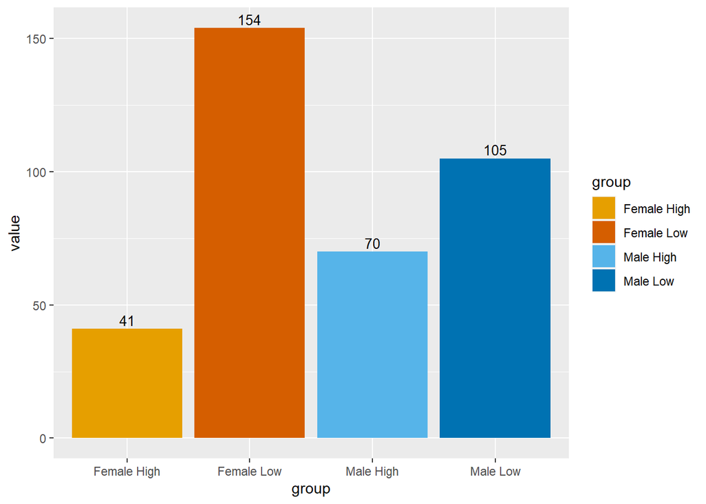

```r
#based on frequency
ggplot(df, aes(x=group, y=value, fill=group)) + #basic plot
  geom_bar(stat="identity") + #define a plot and put groups are side-by-side
  geom_text(aes(label=value), vjust=-0.3, size=3.5) + #add frequencies
  scale_fill_manual(values=c("#E69F00", "#D55E00", "#56B4E9", "#0072B2")) #add colours
```

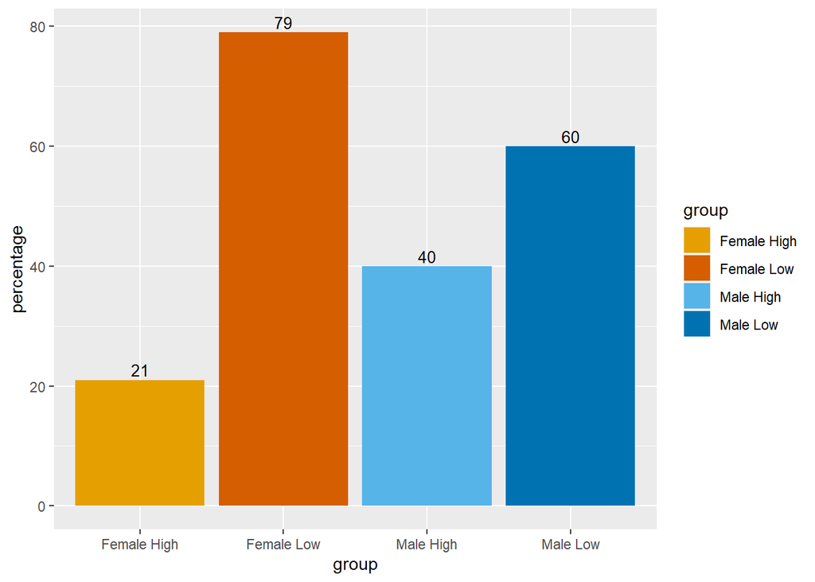

```r
#based on column%
ggplot(df_p, aes(x=group, y=percentage, fill=group)) + #basic plot
  geom_bar(stat="identity") + #define a plot and put groups are side-by-side
  geom_text(aes(label=percentage), vjust=-0.3, size=3.5) + #add frequencies
  scale_fill_manual(values=c("#E69F00", "#D55E00", "#56B4E9", "#0072B2")) #add colours
```

Based on the plot you can also easily to see that based on the column% female participants consumed less alcohol (low=79%, high=21%) in comparison to male students (low=60%, high=40%). This result support our previous hypothesis: *male has higher alcohol consumption than females.* In other words, being a mae might be arisk factor when considering alcohol consumption among students.

**High alcohol consumption (high_use) and absences: summary and boxplot**

Use tapply()-command to search the basic summary of absences-variable.

```r
tapply(alc_a3$absences, alc_a3$high_use, summary)
```

```
## $`FALSE`
##    Min. 1st Qu.  Median    Mean 3rd Qu.    Max.
##    0.00    1.00    3.00    3.71    5.00   45.00
##
## $`TRUE`
##    Min. 1st Qu.  Median    Mean 3rd Qu.    Max.
##   0.000   2.000   4.000   6.378   9.000  44.000
```

Next, we initialize a boxplot of high_use and absences

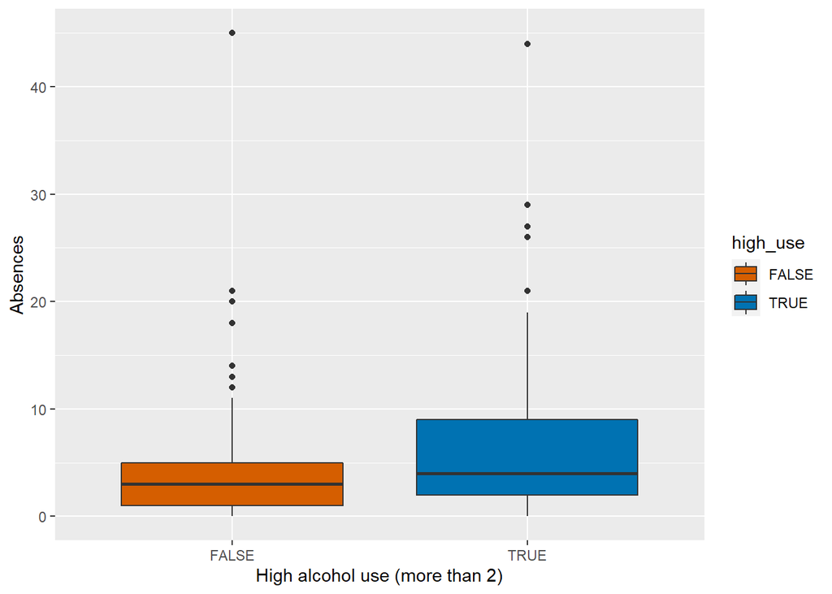

```r
g1 <- ggplot(alc_a3, aes(x = high_use, y = absences, fill=high_use)) + #alcohol consumption with absences (numeric)
  geom_boxplot() + ylab("Absences") + xlab("High alcohol use (more than 2)") +
  scale_fill_manual(values=c("#D55E00", "#0072B2")) #add colours
g1
```

**High alcohol consumption (high_use) and going out with friends (goout: numeric 1=very low to 5=very high): cross-tabulation and barplot**

Creating a cross-tabulation

```r
# Cross-tabulation
t1 <- xtabs(~high_use+goout, data=alc_a3)
ftable(t1) # print table.
```

```
##          goout  1  2  3  4  5
## high_use
## FALSE          19 82 97 40 21
## TRUE            3 15 23 38 32
```

```r
summary(t1) # chi-square test of indepedence.
```

```
## Call: xtabs(formula = ~high_use + goout, data = alc_a3)
## Number of cases in table: 370
## Number of factors: 2
## Test for independence of all factors:
##  Chisq = 55.57, df = 4, p-value = 2.463e-11
```

```r
# or http://rstudio-pubs-static.s3.amazonaws.com/6975_c4943349b6174f448104a5513fed59a9.html
source("http://pcwww.liv.ac.uk/~william/R/crosstab.r")
t1_f = crosstab(alc_a3, row.vars = "high_use", col.vars = "goout", type = "f")
t1_f #frequency count
```

```
##          goout   1   2   3   4   5 Sum
## high_use
## FALSE           19  82  97  40  21 259
## TRUE             3  15  23  38  32 111
## Sum             22  97 120  78  53 370
```

```r
t1_c = crosstab(alc_a3, row.vars = "high_use", col.vars = "goout", type = "c")
t1_c # %column
```

```
##          goout      1      2      3      4      5
## high_use
## FALSE           86.36  84.54  80.83  51.28  39.62
## TRUE            13.64  15.46  19.17  48.72  60.38
## Sum            100.00 100.00 100.00 100.00 100.00
```

Based in the **summary(0)** you can also see that there is a significant difference p<.001, x^2(4)=55.57 between *going out with friends* and *alcohol consumption*. However, the chi-square test **does not** tell where this significant difference is located. However, based on the **col%** we can guess that the difference in alcohol consumption is higher among students who see their friends more often (scoring 4 or 5: F = 51% and 40%; T = 49% and 60%) in comparison students who dont see their friends that often (scoring 1-3: F ~ 80%; T ~ 20%).

Creating a dataframe

```r
# data frame based on frequencies
df_p2 = data.frame(group=c("1 False", "2 False", "3 False", "4 False", "5 False",
                          "1 True", "2 True", "3 True", "4 True", "5 True"),
                percentage=c(86, 85, 81, 51, 40,
                             14, 15, 19, 49, 60))
df_p2
```

```
##      group percentage
## 1  1 False         86
## 2  2 False         85
## 3  3 False         81
## 4  4 False         51
## 5  5 False         40
## 6   1 True         14
## 7   2 True         15
## 8   3 True         19
## 9   4 True         49
## 10  5 True         60
```

Creating a plot - going out with friens (goout) and alcohol consumption (high_use)

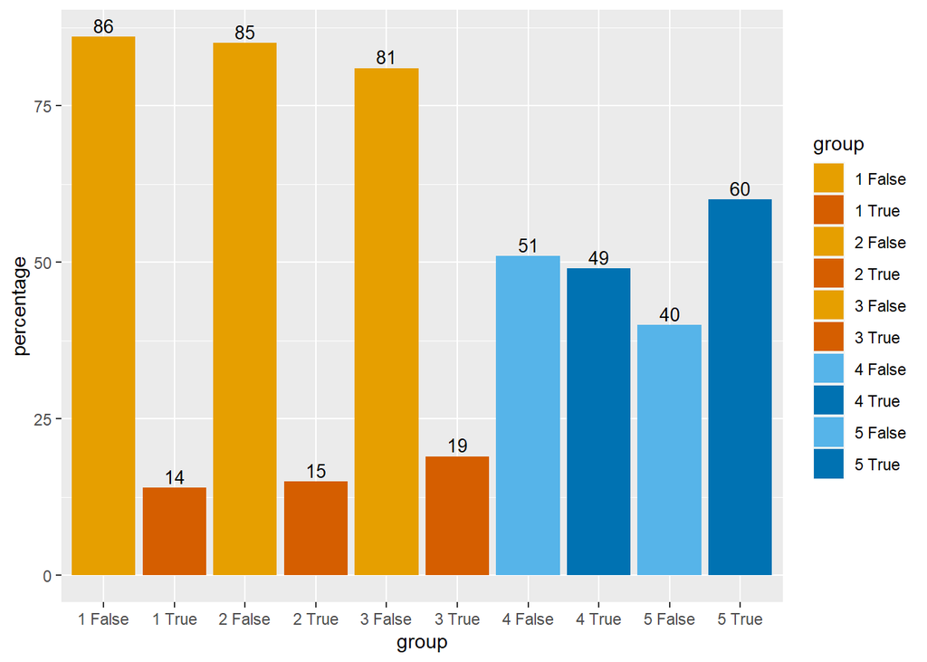

```r
#based on column%
ggplot(df_p2, aes(x=group, y=percentage, fill=group)) + #basic plot
  geom_bar(stat="identity") + #define a plot and put groups are side-by-side
  geom_text(aes(label=percentage), vjust=-0.3, size=3.5) + #add frequencies
  scale_fill_manual(values=c("#E69F00", "#D55E00", "#E69F00", "#D55E00", "#E69F00", "#D55E00","#56B4E9", "#0072B2", "#56B4E9", "#0072B2")) #add colours
```

Based on the plot you can also easily to see that based on the column% studeny who don’t see their friends that often will often have less prevelance of high alcohol consumption, whereas the prevelance for high alcohol consumption seem to be ~50%-50%, or even higher 60%-40% among students who see their friends often. These result support our previous hypothesis: *going out with friends (higher incidence)* is associated with higher risk of *high alcohol consumption*.